# Tvyal Newsletter

Aghasi Tavadyan

2024-05-17

*English summary below.*

Հարգելի գործընկեր,

Հուսով եմ՝ լավ եք: Ներկայացնում եմ այս շաբաթվա վերլուծությունները և աշխատանքները.

## [🔌⚡🇦🇲 էլեկտրիկ Հայաստան․ էլեկտրականության արտադրության և արտահանման կրճատում](https://www.tvyal.com/newsletter/2024/2024_05_17)

2023թ. արևային էլեկտրակայանները կազմել են էլեկտրաէներգիայի արտադրության **8.7 տոկոսը**:

Առաջին գծապատկերում պատկերված է Հայաստանում էլեկտրաէներգիայի ամսական արտադրությունը` ըստ կայանների տեսակների, 2023 թվականի և 2024 թվականի առաջին եռամսյակի համար: Գծապատկերում երևում է էլեկտրականության արտադրության տարբեր աղբյուրների սեզոնայնությունը։

**Գծապատկեր 1.**

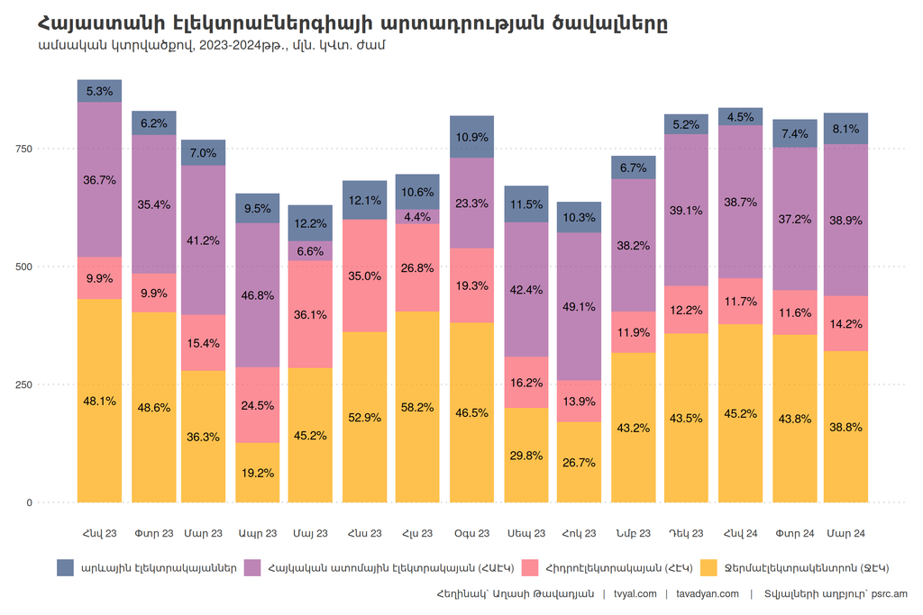

Ծով ելք չունեցող երկրի համար, որը մեծապես կախված է ներկրվող հանածո վառելիքից, արևային էներգիան կարևոր է դառնում մի քանի պատճառներով. նախ արևային էներգիան ապահովում է էներգիայի ապակենտրոնացված աղբյուր՝ նվազեցնելով կախվածությունը արտաքին մատակարարներից և բարելավելով էներգետիկ անվտանգությունը: Նշենք, որ 2023 թվականին 42 տոկոսը կամ 3 715.6 մլն կՎտ ժամը արտադրվել էր ՋԷԿ-ի կողմից, որը օգտագործում է Ռուսաստանից ներմուծված գազ էլեկտրականության արտադրման համար և ներքին շուկայում ամենաթանկ էլեկտրականության աղբյուրն է: Օգտագործելով արևի էներգիան՝ Հայաստանը կարող է զգալիորեն նվազեցնել իր խոցելիությունը աշխարհաքաղաքական լարվածություններից, գների տատանումների և ներմուծվող գազի հետ կապված մատակարարման խափանումներից:

2023 թվականին էլեկտրաէներգիայի արտադրությունը և արտահանումը կրճատվել են, որը որոշակի մտահոգություն է առաջացնում։ 2023 թվականին արտադրվել է 8 845 մլն կՎտ ժամ էլեկտրոէներգիա, իսկ 2022-ին՝ 9 165 մլն կՎտ ժամ։ Փաստացի էլեկտրոէներգիայի արտադրությունը կրճատվել է 3.5%-ով: Բացի արևային էլեկտրաէներգիայի արտադրության, բոլոր այլ հիմնական տեսակների էլեկտրոէներգիայի արտադրությունը կրճատվել է։ ՋԷԿ արտադրությունը կրճատվել է 4.2%, ՀԱԷԿ արտադրությունը՝ 4.8%, իսկ ՀԷԿ-երի արտադրությունը՝ 15.2%: Աճը ապահովել է միայն արևային էլեկտրակայանների արտադրված էլեկտրաէներգիան՝ մոտ 55% աճ։* 2023 թվականին ընդհանուր արտադրված էլեկտրաէներգիայի 8.7% կամ 772 մլն կվտ ժամը ապահովել է այս աղբյուրը։

Իհարկե, արևային էլեկտրաէներգիայի աճը դրական է էներգետիկ անվտանգության ապահովման տեսանկյունից, սակայն ընդհանուր էլեկտրաէներգիայի արտադրության անկումը մտահոգիչ է և կարող է վկայել իրական տնտեսության անկման մասին, քանի որ էլեկտրաէներգիան ապրանք է, որը արդադրությունից հետո միանգամից պետք է սպառվի, և այն հանգամանքը, որ 3.5 տոկոսով ավելի քիչ էլեկտրականություն է արտադրվել 2023 թվականին, քան նախորդ տարի, վկայում է նրա մասին, որ արտադրության պահանջարկը էլեկտրականության նկատմամբ նվազել է։

**Գծապատկեր 2.**

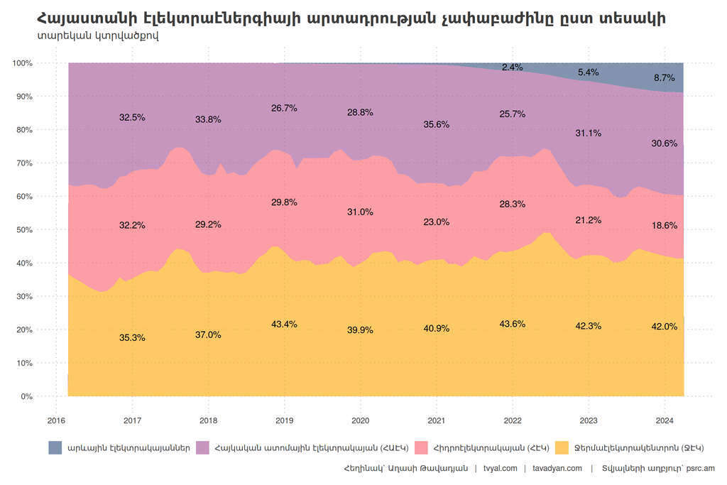

Գծապատկերը արտացոլում է նաև 2024 և 2025 թվականի կանխատեսումները 2 մոդելներով (AUTO.ARIMA և BATS)՝ տալով նաև անորոշության միջակայքը: 2 մեթոդով կանխատեսումն էլ գրեթե համարժեք են 2024 և 2025 թվականի համար, կանխատեսելով, որ արևային էլեկտրաէներգիան այս տարի կազմելու է ընդհանուր արտադրության 9-10 տոկոսը: Այսպիսով, կանխատեսումները ամենայն հավանականությամբ էլեկտրաէներգիայի արտադրության աճ չեն ակնկալում, և այլ հավասար պայմաններում հաջորդ 2 տարիների կտրվածքով 2023 թվականը կարող է լինել էլեկտրականության արտադրության պիկային տարին։

**Գծապատկեր 3.**

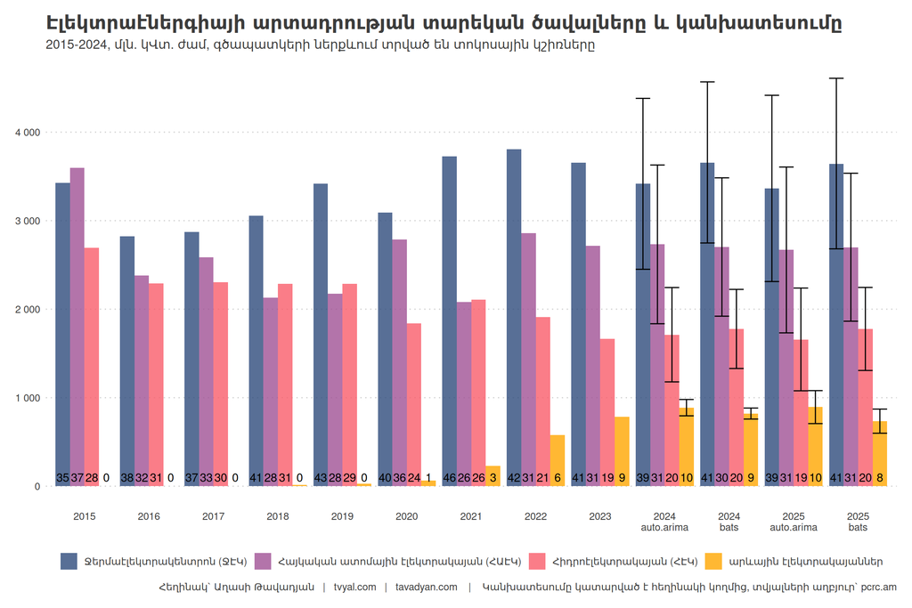

4-րդ գծապատկերում ցուցադրված է Հայաստանում արտադրված էլեկտրաէներգիայի ամսական ծավալները` ըստ էլեկտրակայանների տեսակների: Գծապատկերում տրված է նաև 2 տարվա կանխատեսումը մինչև 2026 թվականը:

Հրազդանի ՋԷԿ-ը, որը այս պահին արտադրում է ամենաշատ էլեկտրաէներգիան, ունի անփոփոխ միտում: Ընդհանուր այս ոլորտում էլեկտրականության արտադրության փոփոխություններ չեն սպասվում:

Գծապատկերում երևում է Հայկական ատոմային էլեկտրակայանի պլանային սեզոնային անջատումները, որոնք 2016 թվականից ի վեր պլանային անջատումներ են` ուղղված ատոմակայանի վերագործարկման և ժամկետի երկարացմանը:

Հիդրոէլեկտրակայանների արտադրությունը ունի նվազման միտում: Եթե 2017 թվականին միջինը ամսական արտադրվում էր մոտ 200 մլն կՎտ ժամ էլեկտրաէներգիա, ապա 2023-ին՝ ամսեկան արդեն մոտ 150 մլն կՎտ ժամ: Սա որոշակի մտահոգություն է առաջացնում վերականգնվող էլեկտրականության աճի ապահովվման տեսանկյունից։ Այստեղ տենդենցը կախված է ջրառի սեզոնայնությամբ, որը արտացոլվում է նաև կանխատեսումների մեջ:

Հայաստանը վերջին տարիներին գտնվում էր արևային էլեկտրաէներգիայի էքսպոնենցիալ աճի կորի վրա, որը հասել է արտադրության գագաթնակետին՝ ըստ մեր կողմից իրականացված կանխատեսումների: Գծապատկերում հստակ երևում է արևային էլեկտրաէներգիայի աճը և սեզոնայնությունը:

**Գծապատկեր 4.**

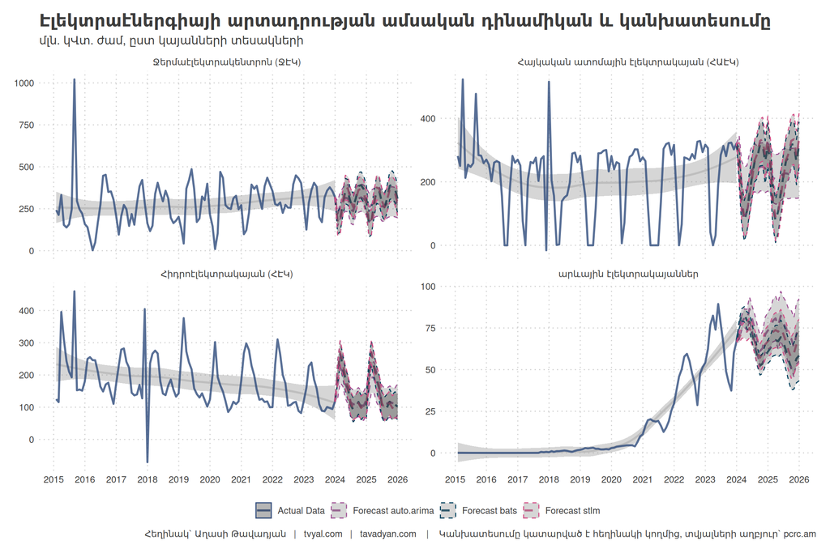

Դիտարկենք նաև էլեկտրականության արտահանումը, որտեղ կրճատումները ավելի էական են։ Ինչպես երևում է գծապատկերում, 2022 թվականին էլեկտրականության արտահանումը ռեկորդային աճ գրանցեց՝ 74.5% (50.9 մլն դոլարից, 88.8 մլն դոլար)։ Սա հիմնականում պայմանավորված էր հետհամաճարակային վերականգնողական աճով և մեծ քանակությամբ կապիտալի ներհոսքով Ռուսատանից։ [Այս պահին գրանցվում է կապիտալի արտահոսք](https://www.tvyal.com/newsletter/2024/2024_03_01)։

2023 թվականին առկա է էլեկտրականության արտահանման անկում՝ 23.4%՝ մինչև 68.0 մլն դոլար և տարեկան կտրվածքով դեռ առկա է արտահնման կտրուկ անկում։ Էլեկտրականությունը հիմնականում արտահանվում է դեպի Իրան՝ գազի դիմաց։ Քանի որ էլեկտրաէներգիան արտադրության ժամանակ պիտի սպառվի, արտահանումը կազմակերպվում է ավելցուկային ժամերին։

> Ձեզ կարող է հետաքրքրել նաև հետևյալ վերլուծությունները.
> - [💸🔚🏦 Կապիտալի արտահոսք](https://www.tvyal.com/newsletter/2024/2024_03_01)։
> - [🤒🟨♻️ Ոսկու տենդի շարունակություն. Հայաստանի արտահանման 75%-ը ոսկի և ադամանդ է](https://www.tvyal.com/newsletter/2024/2024_05_11)։

**Գծապատկեր 5.**

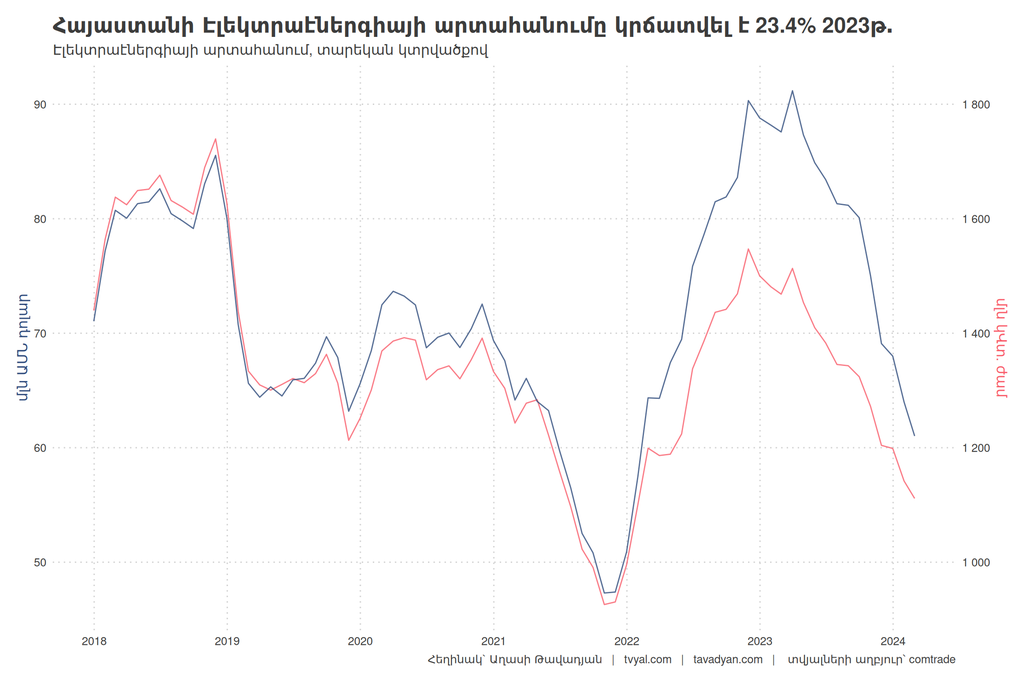

Վերջին գծապատկերը արտացոլում է արդյունաբերական արտադրանքի արտադրության ծավալներնի մեջ էլեկտաէներգիայի արտադրությունը ընթացիկ գներով։ Աղյուսակը տրված է տարեկան կտրվածքով։ Այստեղ նույնպես երևում է էլեկտրականության արտադրության սրընթաց աճը 2022 թվականին։ Ընդհանուր էլեկտրականության արտադրության ծավալը դրամով աճել է 18.3% 2022 թվականին (227.2 մլրդ դրամից մինչև 268.8 մլրդ դրամ)։ 2023 թվականին արդեն գրանցվել է 4.4% անկում՝ մինչև 256.9 մլրդ դրամ, սակայն, ըստ պաշտոնական վիճակագրության, արդյունաբերական արտադրանքի արտադրության ծավալներնի մեջ արդեն առկա է էլեկտականության արտադրության աճ։

**Գծապատկեր 6.**

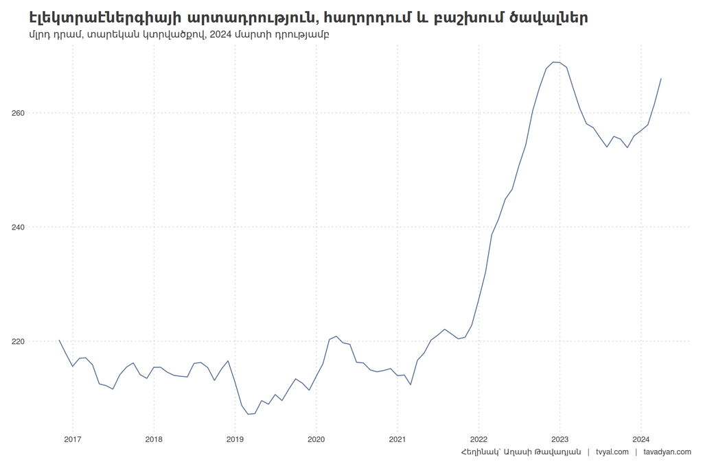

Նշենք, որ աշխարհում առկա է էլեկտրական մեքենաներին և ջեռուցման վերականգնողական միջոցներին անցնելու միտում։ Բնակարանների տաքացման ու մեքենաների լիցքավորման զգալի մասը հնարավոր է, որ ապագայում կատարվելու է էլեկտրականությամբ: Վերջինս կբարձրացնի էլեկտրականության հանդեպ պահանջարկը և այս պարագայում տնային տնտեսությունների սպառման աճը կավելացնի էլեկտրաէներգիայի արտադրությունը։ Սակայն, սա կարող է սթրեսի ենթարկել Հայաստանի էներգետիկ համակարգը, քանի որ, եթե տնային տնտեսությունների մեծամասնությունը անցում կատարեն էլեկտրական մեքենաներին և էլեկտրականությամբ ջեռուցման, ապա սա կմեծացնի էլեկտրաէներգիայի պահանջարկը մոտ 2 անգամ, որի ենթակառուցվածքային հնարավորությունները այս պահին Հայաստանը չունի: Պահանջարկի և առաջարկի հնարավոր կրկնապատկումը կարող է լարվածության տակ դնել էլեկտրական ենթակառուցվածքները, որոնք անհրաժեշտ է հրատապ թարմացնել: Այս ռիսկերից խուսափելու համար անհրաժեշտ է մեծացնել արտադրական հզորությունները և էլեկտրաֆիկացման ենթակառուցվածքների քանակությունը: Այսպես, պետք է որոշակի պլան ներդրված լինի, որ մի քանի տարում Հայաստանի էլեկտրական ենթակառուցվածքները պատրաստ լինեն ապահովել տարեկան 18 000 մլն կՎտ ժամ հոսանք:

* 2023 թվականից առկա է արևային էլեկտրականության արտադրության հաշվարկային փոփոխություն։ Արևային էլեկտրաէներգիայի արտադրության ծավալներում ներառված են նաև էլեկտրաէներգիայի փոխհոսքերի մասով ինքնավար արտադրողների կողմից արտադրված էլեկտրաէներգիայի քանակությունները։ Սա հաշվի առնելու համար մինչև 2023 թվականի արևային էլեկտրականության արտադրության ցուցանիշները ճշգրտվել են։<>

Եթե հնարավոր է, խնդրում եմ այս նյութը ուղարկել նաև այն մարդկանց, ում այն կարծում եք կարող է հետաքրքրել:

**ԱՅՍ ՀՈԴՎԱԾԻ ՀՂՈՒՄԸ**

*Թավադյան, Աղ․Ա․ (2024)․ էլեկտրիկ Հայաստան․ էլեկտրականության արտադրության և արտահանման կրճատում [Electric Armenia: Reduction in Electricity Production and Exports]․ Tvyal.com հարթակ [Tvyal.com platform], 17-05-2024․ https://www.tvyal.com/newsletter/2024/2024_05_17*

**Արգելվում է այս հարթակի նյութերը արտատպել առանց հղում կատարելու։**

* Այս և մեր բոլոր այլ վերլուծությունների տվյալները վերցված են պաշտոնական աղբյուրներից։ Հաշվարկները ամբողջությամբ հասանելի են github-ում, դրանք կարելի է ստուգել` այցելելով [github-ի](https://github.com/tavad/tvyal_newsletter/blob/main/2024/) մեր էջը, որտեղ տրված են տվյալները, հաշվարկների և գծապատկերների կոդը։

# ՀԱՄԱԳՈՐԾԱԿՑՈՒԹՅՈՒՆ

## Եթե ուզում եք ձեր տվյլներից օգուտ քաղել AI գործիքներով` ԴԻՄԵՔ ՄԵԶ

### Մենք առաջարկում ենք

- Extensive databases for finding both international and local leads
- Exclusive reports on the Future of the Armenian Economy
- Work and browser automation to streamline operations and reduce staffing needs
- AI models for forecasting growth and optimizing various aspects of your business
- Advanced dashboarding and BI solutions
- Algorithmic trading

### Let’s Put Your Data to Work!

### ՄԻԱՑԵՔ ՄԵՐ ԹԻՄԻՆ

## ԶԼՄ հաղորդագրություն

[Դիտեք 1in.am լրատվամիջոցին տված իմ վերջին հարցազրույցը, եթե ուզում եք իմանալ ապագա տնտեսական աճի պատճառների մասին։](https://youtu.be/6zQQjlQImMI)

📺 Ոսկու առեղծվածը․ 9 անգամ աճել է ոսկու արտահանումը. Աղասի Թավադյան 📺

[figure not shown]

## English Summary

### 🔌⚡🇦🇲 Electric Armenia: Reduction in Electricity Production and Exports

Armenia’s energy landscape faces notable shifts, as evidenced by recent statistics. Analysis reveals a concerning trend of decreasing electricity production and exports. In 2023, total electricity production witnessed a 3.5% decline compared to the previous year, with reductions across major production types such as CHP, NPP, and HEC. Only solar electricity production saw a remarkable increase of approximately 55%, albeit accounting for a modest 8.7% of total electricity generated. Moreover, the export of electricity experienced a significant downturn, plummeting by 23.4% to 68.0 million dollars in 2023. This trend underscores challenges in maintaining production demand amid geopolitical and economic uncertainties.

The decline in production and exports poses multifaceted challenges for Armenia’s energy security and economic stability. While solar energy adoption offers promise in reducing reliance on imported fossil fuels and enhancing energy resilience, the overall shrinkage in electricity metrics raises concerns about the nation’s economic vitality. Notably, the shift towards electric vehicles and heating solutions globally may amplify electricity demand, further straining Armenia’s energy infrastructure. Addressing these challenges necessitates strategic planning and investment to bolster production capacity and electrification infrastructure, ensuring readiness to meet future demand projections. Thus, amidst shrinking production and export figures, proactive measures are imperative to fortify Armenia’s energy sector and sustain its economic growth trajectory.

Այս վերլուծությունը առկա է նաև [մեր կայքէջում](https://www.tvyal.com/newsletter/2024/2024_05_17), այս վերլուծության կոդը և տվյալները դրված են նաև [Github-ում](https://github.com/tavad/tvyal_newsletter)։

Եթե հնարավոր է, խնդրում եմ այս նյութը ուղարկել նաև այն մարդկանց, ում այն կարծում եք կարող է հետաքրքրել:

Սպասեք հաջորդ հաղորդագրությանը հաջորդ ուրբաթ օրը:

Հարգանքներով,  
Աղասի Թավադյան  
17.05.2024  
[tvyal.com](https://www.tvyal.com/)  
[tavadyan.com](https://www.tavadyan.com/)

[Was this email forwarded to you? Subscribe here.](https://www.tvyal.com/subscribe)

[Բաժանորդագրվեք](https://www.tvyal.com/subscribe)

**Ուշադրություն. Ձեր էլ.փոստը մեյլլիսթի մեջ է, որի միջոցով ես կիսվում եմ շաբաթական նյութեր, որոնք հիմնականում ներկայացնում են Հայաստանի տնտեսությունը: Նյութերը ներառում են գծապատկերներ, [տվյալների բազաներ](https://github.com/tavad/tvyal_newsletter), տեսանյութեր, հոդվածներ, [առցանց վահանակներ](https://www.tvyal.com/projects), տնտեսական գործիքներ, կանխատեսումներ և հաշվետվություններ: Եթե ցանկանում եք չեղարկել բաժանորդագրությունը, խնդրում եմ տեղեկացրեք ինձ, և ես կհեռացնեմ ձեր էլ. փոստը ցուցակից: Գրեք նաև եթե ունեք մենկնաբանություններ:**

**Important! Your email is part of the mailing list where I share weekly materials primarily focused on the Armenian economy. These materials encompass charts, [databases](https://github.com/tavad/tvyal_newsletter), videos, articles, [online dashboards](https://www.tvyal.com/projects), economic tools, forecasts, and reports. If you wish to unsubscribe, please let me know, and I will remove your email from the list. Please share your comments as well․**